# STAT 360: Computational Statistics and Data Analysis

#### Part (c)

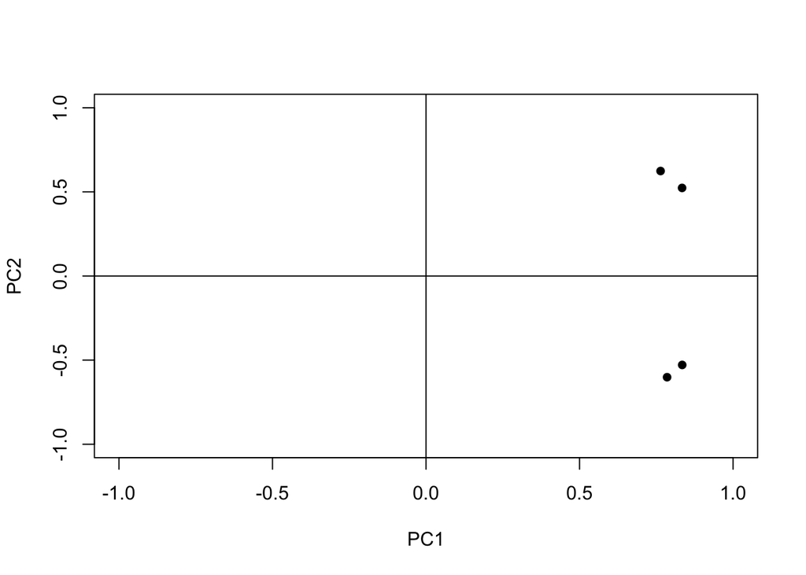

```r
# Insert code or written answer here
plot(A2, pch = 16, xlab = "PC1", ylab = "PC2",
     xlim = c(-1,1), ylim = c(-1,1))
abline(h = 0, v = 0)
```

#### Part (d)

```r
# Written answer below
```

Orthogonal rotation appears to be needed because both factors appear to be complex. All of the points on the graph above exhibit substantial loading on to both factors, all data points are in the spaces in between axes. Orthogonal rotation appears to be able to help to increase the purity of the factors, as a counterclockwise rotation of the axes of about 45 degrees would make all of the points much further away from the spaces in between axes.

#### Part (e)

```r
# Insert code or written answer here
psi2 <- 45 * pi / 180
PSI2 <- matrix(c(cos(psi2), -sin(psi2),
                sin(psi2), cos(psi2)), nrow = 2, ncol = 2, byrow = T)
PSI2
```

```
##           [,1]       [,2]
## [1,] 0.7071068 -0.7071068
## [2,] 0.7071068  0.7071068
```

#### Part (f)

```r
# Insert code or written answer here
A12 <- A2 %*% PSI2
A12
```

```
##                  [,1]        [,2]
## Water       0.2161727 -0.96371801
## Electricity 0.1297591 -0.98048067
## Sanitation  0.9814130 -0.09892852
## Education   0.9598499 -0.21947599
```

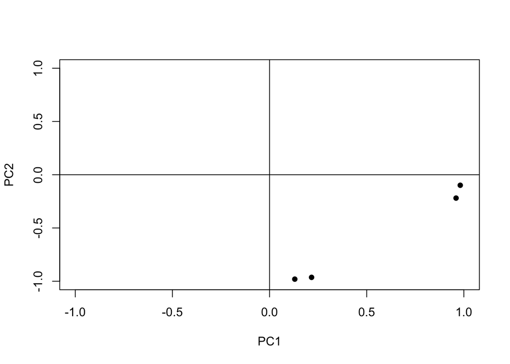

```r
plot(A12, pch = 16, xlab = "PC1", ylab = "PC2",
     xlim = c(-1,1), ylim = c(-1,1))
abline(h = 0, v = 0)
```

### Exercise 2.11 - Facework in Intercultural Communication (continued)

#### Part (a)

```r
# Insert code or written answer here
faceWork <- matrix(c(1, 0.35, 0.36, 0.19, 0.12, 0.18, 0.21, 0.23, -0.15, -0.13,
                     0.35, 1, 0.28, 0.41, 0.17, 0.03, 0.06, 0.24, 0.01, -0.12,
                     0.36, 0.28, 1, 0.4, 0.23, 0.27, 0.25, 0.32, -0.21, -0.07,
                     0.19, 0.41, 0.4, 1, 0.24, 0.24, 0.27, 0.21, -0.09, 0.05,
                     0.12, 0.17, 0.23, 0.24, 1, 0.75, 0.74, -0.01, 0.34, 0.29,
                     0.18, 0.03, 0.27, 0.24, 0.75, 1, 0.78, 0.12, 0.12, 0.26,
                     0.21, 0.06, 0.25, 0.27, 0.74, 0.78, 1, 0.17, 0.06, 0.24,
                     0.23, 0.24, 0.32, 0.21, -0.01, 0.12, 0.17, 1, -0.35, -0.27,
                     -0.15, 0.01, -0.21, -0.09, 0.34, 0.12, 0.06, -0.35, 1, 0.27,
                     -0.13, -0.12, -0.07, 0.05, 0.29, 0.26, 0.24, -0.27, 0.27, 1), nrow = 10, ncol = 10, byrow = T, dimnames = list(c("1. Self-positive face", "2. Self-negative face", "3. Other-positive face", "4. Other-negative face", "5. Severity", "6. Threatened positive face ", "7. Threatened negative face", "8. Unintentional attribution", "9. Intentional attribution", "10. Incidental attribution "), c("1", "2", "3", "4", "5", "6", "7", "8", "9", "10")))
faceWork
```

```
##                                  1     2     3     4     5    6    7     8
## 1. Self-positive face         1.00  0.35  0.36  0.19  0.12 0.18 0.21  0.23
## 2. Self-negative face         0.35  1.00  0.28  0.41  0.17 0.03 0.06  0.24
## 3. Other-positive face        0.36  0.28  1.00  0.40  0.23 0.27 0.25  0.32
## 4. Other-negative face        0.19  0.41  0.40  1.00  0.24 0.24 0.27  0.21
## 5. Severity                   0.12  0.17  0.23  0.24  1.00 0.75 0.74 -0.01
## 6. Threatened positive face   0.18  0.03  0.27  0.24  0.75 1.00 0.78  0.12
## 7. Threatened negative face   0.21  0.06  0.25  0.27  0.74 0.78 1.00  0.17
## 8. Unintentional attribution  0.23  0.24  0.32  0.21 -0.01 0.12 0.17  1.00
## 9. Intentional attribution   -0.15  0.01 -0.21 -0.09  0.34 0.12 0.06 -0.35
## 10. Incidental attribution   -0.13 -0.12 -0.07  0.05  0.29 0.26 0.24 -0.27
##                                  9    10
## 1. Self-positive face        -0.15 -0.13
## 2. Self-negative face         0.01 -0.12
## 3. Other-positive face       -0.21 -0.07
## 4. Other-negative face       -0.09  0.05
## 5. Severity                   0.34  0.29
## 6. Threatened positive face   0.12  0.26
## 7. Threatened negative face   0.06  0.24
## 8. Unintentional attribution -0.35 -0.27
## 9. Intentional attribution    1.00  0.27
## 10. Incidental attribution    0.27  1.00
```

#### Part (b)

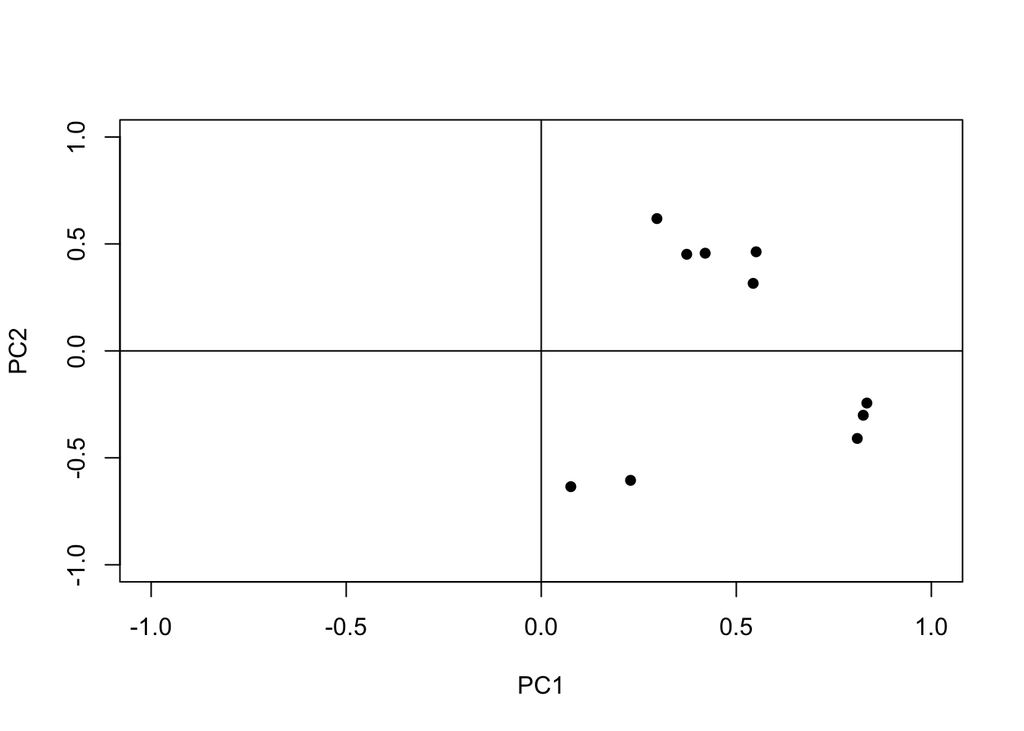

```r
# Insert code or written answer here
# library(psych)
A3 <- pca(r = faceWork, nfactors = 2, rotate = "none")$loadings[]
plot(A3, pch = 16, xlab = "PC1", ylab = "PC2",
     xlim = c(-1,1), ylim = c(-1,1))
abline(h = 0, v = 0)
```

#### Part (c)

```r
# Written answer below
```

There does appear to be complexity among the original dimensions, as the top cloud of points is about centered at (0.5,0.5) on the factor loading plot, which is above the 0.3 threshold on both the PC1 dimension and the PC2 dimension. Stated another way, this cloud of points falls in the space between the PC1 and PC2 axes and so is likely to be complex because those points exhibit substantial loading on both factors.

#### Part (d)

```r
# Insert code or written answer here
A23 <- pca(r = faceWork, nfactors = 2, rotate = "varimax")$loadings[]
A23
```

```
##                                      RC1        RC2
## 1. Self-positive face         0.08832622  0.6143115
## 2. Self-negative face         0.05214748  0.5833972
## 3. Other-positive face        0.19235306  0.6935980
## 4. Other-negative face        0.26956911  0.5675255
## 5. Severity                   0.89969099  0.1204027
## 6. Threatened positive face   0.85093712  0.2185110
## 7. Threatened negative face   0.82635479  0.2707734
## 8. Unintentional attribution -0.10523387  0.6778069
## 9. Intentional attribution    0.42148021 -0.4807166
## 10. Incidental attribution    0.53106440 -0.3697253
```

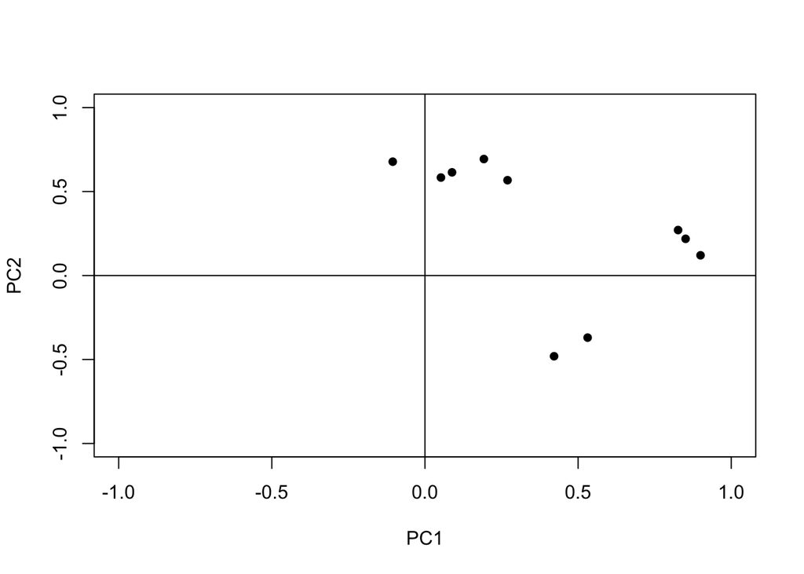

```r
plot(A23, pch = 16, xlab = "PC1", ylab = "PC2",
     xlim = c(-1,1), ylim = c(-1,1))
abline(h = 0, v = 0)
```

#### Part (e)

```r
# Written answer below
```

There is remaining complexity in this optimally rotated loading matrix, as the bottom cloud of point have been rotated such that the center of that cloud would be around (0.5,-0.5). Stated another way, this cloud of points falls in the space between the PC1 and PC2 axes and so is likely to be complex because those points exhibit substantial loading on both factors. This being said, this optimally rotated loading matrix is optimal because the number of points which are complex has decreased from 5 to 2.

#### Part (f)

```r
# Written answer below
```

Non-orthogonal rotation would not be effective without the addition of another axis/factor. The two axes/factors themselves cannot be rotated or manipulated in such a way that there is not going to be at least some cloud of points/original dimensions that is complex. As such another axis/factor is needed to further purify the loading matrix.

### Exercise 2.12 - Residential Property Values in Ames, Iowa (continued)

#### Part (a)

```r
# Insert code or written answer here
ames <- matrix(c(1656, 215000,  20, 141, 31770, 6, 1960, 1960,
                  896, 105000,  20,  80, 11622, 5, 1961, 1961,
                 1329, 172000,  20,  81, 14267, 6, 1958, 1958,
                 2110, 244000,  20,  93, 11160, 7, 1968, 1968,
                 1629, 189900,  60,  74, 13830, 5, 1997, 1998,
                 1604, 195500,  60,  78,  9978, 6, 1998, 1998,
                 1338, 213500, 120,  41,  4920, 8, 2001, 2001,
                 1280, 191500, 120,  43,  5005, 8, 1992, 1992,
                 1616, 236500, 120,  39,  5389, 8, 1995, 1996,
                 1804, 189000,  60,  60,  7500, 7, 1999, 1999,
                 1655, 175900,  60,  75, 10000, 6, 1993, 1994,
                 1187, 185000,  20,  NA,  7980, 6, 1992, 2007,
                 1465, 180400,  60,  63,  8402, 6, 1998, 1998,
                 1341, 171500,  20,  85, 10176, 7, 1990, 1990,
                 1502, 212000, 120,  NA,  6820, 8, 1985, 1985,
                 3279, 538000,  60,  47, 53504, 8, 2003, 2003,
                 1752, 164000,  50, 152, 12134, 8, 1988, 2005,
                 1856, 394432,  20,  88, 11394, 9, 2010, 2010,
                  864, 141000,  20, 140, 19138, 4, 1951, 1951,
                 2073, 210000,  20,  85, 13175, 6, 1978, 1988),
                   byrow = T, nrow = 20, ncol = 8,
                     dimnames = list(c(526301100,526350040,526351010,526353030,527105010,527105030,527127150,527145080,527146030,527162130,527163010,527165230,527166040,527180040,527182190,527216070,527225035,527258010,527276150,527302110), c("Area","Price","Subclass","Lot Frontage","Lot Area","Quality","Built","Remodel")))
ames
```

```
##           Area  Price Subclass Lot Frontage Lot Area Quality Built Remodel
## 526301100 1656 215000       20          141    31770       6  1960    1960
## 526350040  896 105000       20           80    11622       5  1961    1961
## 526351010 1329 172000       20           81    14267       6  1958    1958
## 526353030 2110 244000       20           93    11160       7  1968    1968
## 527105010 1629 189900       60           74    13830       5  1997    1998
## 527105030 1604 195500       60           78     9978       6  1998    1998
## 527127150 1338 213500      120           41     4920       8  2001    2001
## 527145080 1280 191500      120           43     5005       8  1992    1992
## 527146030 1616 236500      120           39     5389       8  1995    1996
## 527162130 1804 189000       60           60     7500       7  1999    1999
## 527163010 1655 175900       60           75    10000       6  1993    1994
## 527165230 1187 185000       20           NA     7980       6  1992    2007
## 527166040 1465 180400       60           63     8402       6  1998    1998
## 527180040 1341 171500       20           85    10176       7  1990    1990
## 527182190 1502 212000      120           NA     6820       8  1985    1985
## 527216070 3279 538000       60           47    53504       8  2003    2003
## 527225035 1752 164000       50          152    12134       8  1988    2005
## 527258010 1856 394432       20           88    11394       9  2010    2010
## 527276150  864 141000       20          140    19138       4  1951    1951
## 527302110 2073 210000       20           85    13175       6  1978    1988
```

#### Part (b)

```r
# Insert code or written answer here
AmesCorMatrix <- cor(ames, use="pairwise.complete.obs")
A4 <- pca(r = AmesCorMatrix, nfactors = 4, rotate = "none")$loadings[]
print(paste("total number of complex dimensions: ", length(which(rowSums(A4 > 0.3 | A4 < -0.3) > 1))))
```

```
## [1] "total number of complex dimensions:  7"
```

#### Part (c)

```r
# Insert code or written answer here
A24 <- pca(r = AmesCorMatrix, nfactors = 4, rotate = "varimax")$loadings[]
print(paste("total number of complex dimensions in optimally rotated matrix: ", length(which(rowSums(A24 > 0.3 | A4 < -0.3) > 1))))
```

```
## [1] "total number of complex dimensions in optimally rotated matrix:  3"
```

#### Part (d)

```r
# Written answer below
```